# Estatística Descritiva no Software R

Nome: Rafael Lima de Souza

RU: 1237272

Polo: Porto Alegre - Centro Histórico

e-mail: ls.rafael@icloud.com

27 January 2019

# Introdução Sobre o R

O R é uma linguagem de programação estatística, trata-se de uma linguagem de programação especializada em computação de dados. Algumas de suas principais características são o seu caráter gratuito e sua disponibilidade para uma gama bastante variada de sistemas operacionais. É também altamente expansível com o uso de pacotes que são bibliotecas para áreas de estudos ou funções específicas, onde é possível executar cálculos complexos e ainda gerar uma infinidade de gráficos.

Ainda é possível contar com um [ambiente de desenvolvimento integrado](https://pt.wikipedia.org/wiki/Ambiente_de_desenvolvimento_integrado), o [RStudio](https://www.rstudio.com), onde é possível gerar relatórios e apresentações com alto nível de qualidade. Inclusive, este trabalho foi totalmente desenvolvido com o editor [R Markdown](https://rmarkdown.rstudio.com).

O código fonte desde trabalho podem ser encontrado no repositório [Estatística Descritiva com R](https://github.com/ralsouza/Estatistica_Descritiva_R) no [GitHub](https://github.com) e o trabalho destaca os links que podem ser acessados para o leitor ver os detalhes dos termos usados neste trabalho.

### Medição dos Dados

Para os cálculos deste relatório, usamos as funções nativas do R, que foram desenvolvidas préviamente pelos desenvolvedores. Abaixo analisaremos as medidas de tendência central conhecidas por Mediana, [Média](https://pt.wikipedia.org/wiki/M%C3%A9dia) e as medidas de dispersão chamadas de [Variância](https://pt.wikipedia.org/wiki/Vari%C3%A2ncia) e o [Desvio Padrão](https://pt.wikipedia.org/wiki/Desvio_padr%C3%A3o).

#### Mediana

A mediana de um conjunto de dados é o valor que ocupa a posição central, desde que estejam colocados em ordem crescente ou decrescente, ou seja, em um rol.

A fórmula da Mediana é: $Md = \frac{n+1}{2}$, desta forma é possível encontrar a posição da mediana.

#### Média

A média aritimética simples, ou simplesmente média, nada mais é que a soma dos resultados obtidos dividida pela quantidade dos resultados.

A fórmula da Média é: $\ \overline{X} = \frac{\sum{X_i}}{n}$, em que $i$ varia de 1 até $n$.

A função utilizada para calcular a Média no R, é chamada de mean.

#### Variância

Como a soma dos desvios em relação à média é sempre igual a zero, é possível evitar este fato elevando cada desvio ao quadrado, pois sabemos que o quadrado de qualquer número real é sempre positivo.

Para calcular a variância de uma população, usamos a seguinte fórmula: $S^2=\frac{\sum[(X_i-\ \overline{X})^2.f_i]}{N}$

Quando se trata de calcular uma amostra, a seguinte fórmula deve ser aplicada: $S^2=\frac{\sum[(X_i-\ \overline{X})^2.f_i]}{N-1}$

A função utilizada para calcular a Variância no R, é chamada de var.

#### Desvio Padrão

O desvio padrão o quanto os dados estão dispersos em torno da média. Um desvio padrão alto, indica que os dados estão espalhados por uma ampla gama de valores. O desvio padrão, nada mais é do que a raíz quadrada da variância.

Sua fórmula para medir a variabilidade dos dados em uma população, é: $S^2=\sqrt{\frac{\sum[(X_i-\ \overline{X})^2.f_i]}{N}}$

E para fazermos a medição em uma amostra, usamos: $S^2=\sqrt{\frac{\sum[(X_i-\ \overline{X})^2.f_i]}{N-1}}$

A função utilizada para calcular o Desvio Padrão no R, é chamada de sd.

## Experimento 1 - Acidentes de Trânsito

A tabela abaixo mostra o número de acidentes de trânsito durante uma semana em uma grande metrópole.

```r
# Criação de um objeto do tipo matriz(7x4), para armazenar os dados dos acidentes.
mt_acidentes <- matrix(c(70,42,45,42,50,61,72,25,15,22,23,24,36,40,
                         75,54,32,30,42,50,52,20,5 ,6 ,5 ,8 ,15,18),
                       nrow = 7,
                       ncol = 4)

# Nomeando os nomes das variáveis e observações.
row.names(mt_acidentes) <- c('Domingo','Segunda','Terça','Quarta','Quinta','Sexta','Sábado')
colnames(mt_acidentes) <- c('Sem Vítimas','Com Ferimentos Graves','Com Ferimentos Leves','Com Mortos')
```

### Resultado do Experimento 1

Como resultado dos comandos acima, obtemos a seguinte tabela com os dados sobre os acidentes ocorridos durante uma semana.

Tabela 1 - Número de Acidentes de Trânsito na Metrópole A

|  | Sem Vítimas | Com Ferimentos Graves | Com Ferimentos Leves | Com Mortos |
| --- | --- | --- | --- | --- |
| Domingo | 70 | 25 | 75 | 20 |
| Segunda | 42 | 15 | 54 | 5 |
| Terça | 45 | 22 | 32 | 6 |
| Quarta | 42 | 23 | 30 | 5 |
| Quinta | 50 | 24 | 42 | 8 |
| Sexta | 61 | 36 | 50 | 15 |
| Sábado | 72 | 40 | 52 | 18 |

Fonte:  
Autor do portifolio.

### Análise dos Dados de Acidentes

Abaixo segue o código usado para calcular as medidas dos dados dos acidentes.

```r
# Comando usado para calcular as medidas e armazenar os dados em um dataframe
df_ferimentos_graves <-  data.frame(tipo    = c('Sem Vítimas','Com Ferimentos Graves','Com Ferimentos Leves','Com Mortos'),
                                     media   = apply(mt_acidentes,2, mean),
                                     des.padr  = apply(mt_acidentes,2, sd),
                                     var     = apply(mt_acidentes,2, var),
                                     mediana = apply(mt_acidentes,2, median))
# Remove os nomes das linhas
row.names(df_ferimentos_graves) <- NULL
```

Podemos constatar abaixo, que a média dos feridos gravemente foi de 26 e o desvio padrão foi 8. Este desvio padrão indica que existe boa aderência da variabilidade dos dados com a média.

Resultados das Medidas Centrais e Dispersão

| tipo | media | des.padr | var | mediana |
| --- | --- | --- | --- | --- |
| Sem Vítimas | 54.57143 | 12.985340 | 168.61905 | 50 |
| Com Ferimentos Graves | 26.42857 | 8.618916 | 74.28571 | 24 |
| Com Ferimentos Leves | 47.85714 | 15.279928 | 233.47619 | 50 |
| Com Mortos | 11.00000 | 6.480741 | 42.00000 | 8 |

No seguinte gráfico podemos analisar visualmente os dados de cada tipo de acidente e constatar que o desvio padrão possui relativa aderência à média.

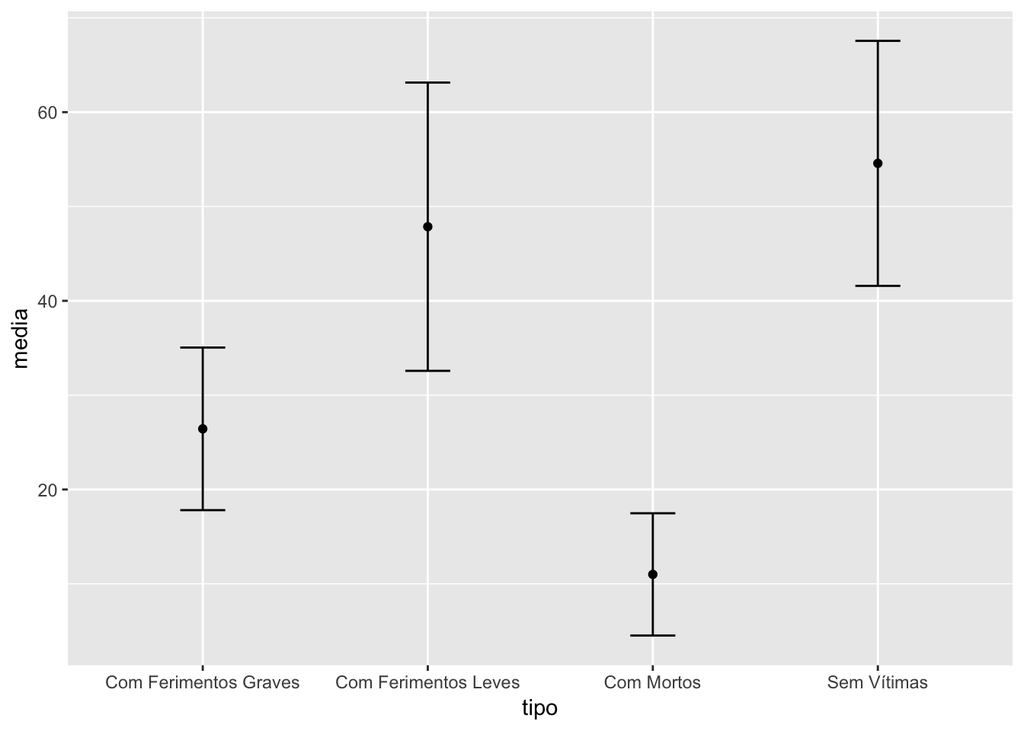

```r
# Biblioteca GGPLOT2 para visualização de dados
ggplot(df_ferimentos_graves, aes(x=tipo, y=media)) +
  geom_errorbar(aes(ymin=media-des.padr, ymax=media+des.padr), width=.2) +
  geom_line() +
  geom_point()
```

## Experimento 2 - Gráficos Bioma Pampa

```r
# Criação de um objeto do tipo matriz(7x4), para armazenar os dados dos acidentes.
mt_bioma <- matrix(c(176496, 6210, 3340, 1607, 122682, 20974, 7658, 14025,
                         13835, 0   , 0   , 428 , 10980 , 2033 , 394 , 0    ,
                         58636 , 6210, 3340, 1179, 21702 , 18940, 7264, 0   ),
                       nrow = 8,
                       ncol = 3)

# Nomeando os nomes das variáveis e observações.
row.names(mt_bioma) <- c('Área Total',
                             'Floresta Estacional Semidecidual',
                             'Floresta Estacional Decidual',
                             'Savana Estépica',
                             'Estepe',
                             'Formações pioneiras',
                             'Contatos entre tipos de vegetação',
                             'Superfície com água')
colnames(mt_bioma) <- c('Total do bioma (Km²)','Área remanescente (Km²)','Área antroponizada (Km²)')
```

Tabela 2 - Áreas Remanescentes e Áreas Antropizadas, no Bioma Pampa, Segundo os Tipos de Vegetação

|  | Total do bioma (Km²) | Área remanescente (Km²) | Área antroponizada (Km²) |
| --- | --- | --- | --- |
| Área Total | 176496 | 13835 | 58636 |
| Floresta Estacional Semidecidual | 6210 | 0 | 6210 |
| Floresta Estacional Decidual | 3340 | 0 | 3340 |
| Savana Estépica | 1607 | 428 | 1179 |
| Estepe | 122682 | 10980 | 21702 |
| Formações pioneiras | 20974 | 2033 | 18940 |
| Contatos entre tipos de vegetação | 7658 | 394 | 7264 |
| Superfície com água | 14025 | 0 | 0 |

Fonte:  
FIGUEIREDO, 2016

#### Apresentação dos Gráficos das Áreas Antropizadas

Abaixo seguem os gráficos relativos a tabela apresentada anteriormente.

##### Percetuais das Áreas Remanescentes e Antroponizadas

No gráfico que segue, podemos analisar o percentual dos totais do bioma pampa. A porcão das áreas antroponizadas são superiores às remanescentes.

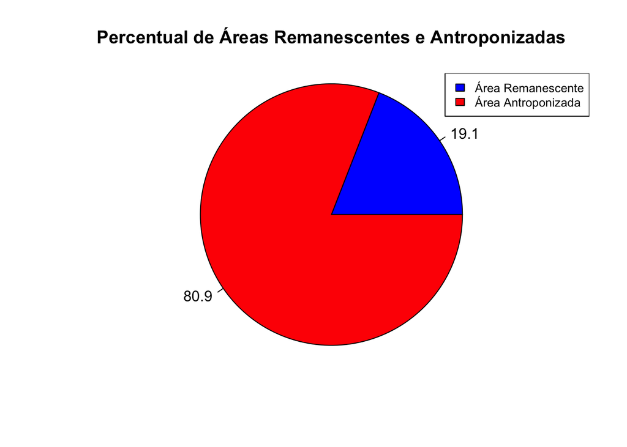

```r
# Nomando os rótulos do gráfico
labels <- c('Área Remanescente','Área Antroponizada')

# Cálculo do percentual dos setores
perc <- round(100*mt_bioma[1,2:3]/sum(mt_bioma[1,2:3]), 1)

# Plot do gráfico
pie(mt_bioma[1,2:3],
    labels = perc,
    main = 'Percentual de Áreas Remanescentes e Antroponizadas',
    radius = 1,
    col = c('blue','red'))

# Ajuste das legendas
legend("topright", c('Área Remanescente','Área Antroponizada'), cex = 0.8,
       fill = c('blue','red'))
```

#### Quantitativos das Áreas Remanescentes e Antroponizadas

No gráfico seguinte podemos analisar os valores quantitativos das áreas do bioma pampa. Podemos concluir que analisando pelos tipos de biomas, temos as áreas atroponizadas em maior quantidade.

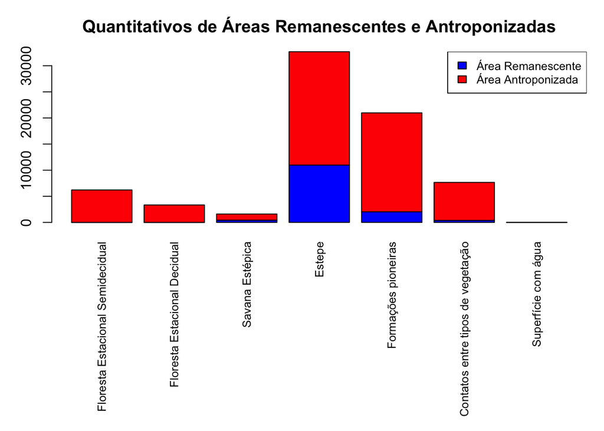

```r
# Ajustes dos rótulos
par(las=3)
par(mar=c(12,3,3,1))

# Criaçãodo Gráfico de colunas
barplot(t(mt_bioma[2:8,2:3]),
        col = c('blue','red'),
        cex.names = 0.8,
        main = 'Quantitativos de Áreas Remanescentes e Antroponizadas')

# Ajustes das legendas
legend("topright", c('Área Remanescente','Área Antroponizada'),
       cex = 0.8,
       fill = c('blue','red'))
```

### Referências

- Nelson Pereira Castanheira; Estatística Aplicada a Todos os Níveis: 2a Edição 2018;
- Manual R Project. Disponível em: https://cran.r-project.org/manuals.html Acesso em: 23 de janeiro de 2018.